# Group Predictions

#### CBS Sports

This week we beat or tied 7 of 8 CBS Sports’ Experts.

For the season we are currently beating or tied with 4 of 8 CBS Sports’ Experts.

#### ESPN

We also beat or tied 4 of 6 ESPN Experts.

For the season we are currently beating or tied with 6 of 9 ESPN Experts.

### Win percentage for the week

[interactive chart not shown]

### Season Win Percentage

[interactive chart not shown]

### Games Correct

172

### Games Picked

273

### Number of predictions

12

This Week's Predictions

Week 21

| Game | Prediction | Winner | Correct | Correct Votes | Correct Percent |
| --- | --- | --- | --- | --- | --- |
| 1 | Philadelphia Eagles | Philadelphia Eagles | Yes | 10 | 0.8333 |
| 2 | Cincinnati Bengals | Kansas City Chiefs | No | 5 | 0.4167 |

[interactive chart not shown]

# Individual Predictions

#### Best Picks of the Week.

Jeremy Reynolds, Gabriel Costa, Josephine Cammack, Margaret Reynolds

#### Best Season Correct Percentage

David Bierbrauer

#### Best Adjusted Season Correct Percentage

Jeremy Reynolds, Daniel Baller, Ira Crofford

- Adjusted season percentage accounts for the number of weeks picked.

## row

### Individual Table

Individual Results

Week 21

Name

Weekly # Correct

Percent

Weeks Picked

Season Percent

Adj Season Percent

Season Trend

Week 1

Week 2

Week 3

Week 4

Week 5

Week 6

Week 7

Week 8

Week 9

Week 10

Week 11

Week 12

Week 13

Week 14

Week 15

Week 16

Week 17

Week 18

Week 19

Week 20

Week 21

Jeremy Reynolds

9

11

8

11

11

7

9

11

9

6

11

11

11

8

10

10

11

11

4

3

2

1.0

21

0.6740

0.6740

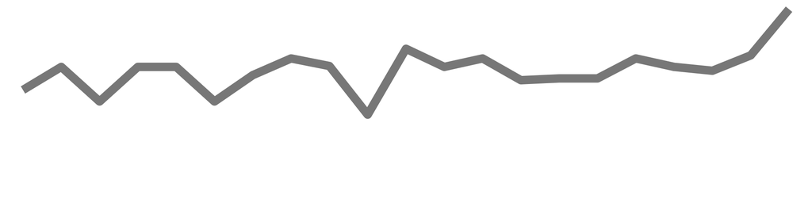

Gabriel Costa

9

10

7

6

12

11

10

7

9

7

9

8

9

9

13

8

10

10

5

2

2

1.0

21

0.6337

0.6337

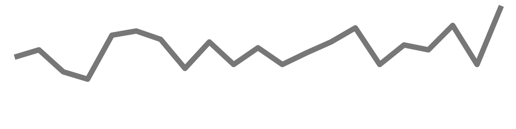

Josephine Cammack

10

7

5

9

10

7

7

9

9

6

9

10

9

8

9

11

11

10

4

3

2

1.0

21

0.6044

0.6044

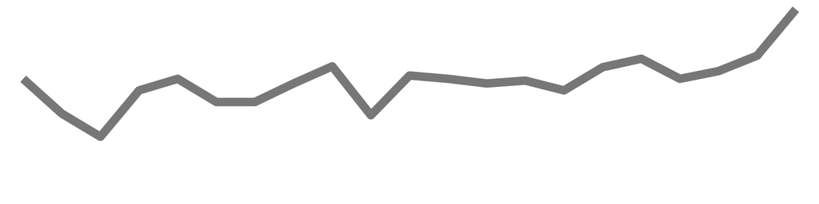

Margaret Reynolds

9

9

6

9

8

5

9

8

9

13

7

8

10

7

9

10

11

8

4

3

2

1.0

21

0.6007

0.6007

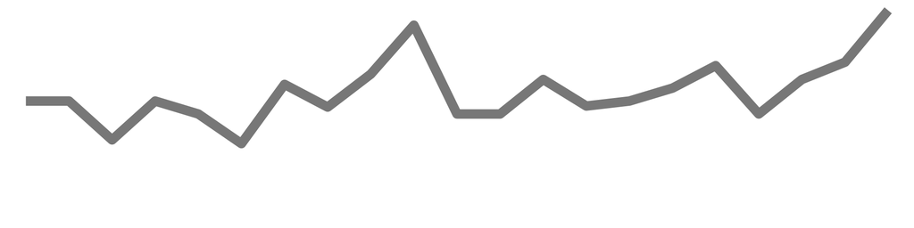

David Bierbrauer

8

8

8

11

10

NA

8

11

10

6

13

11

10

10

10

10

12

NA

5

3

1

0.5

19

0.6790

0.6143

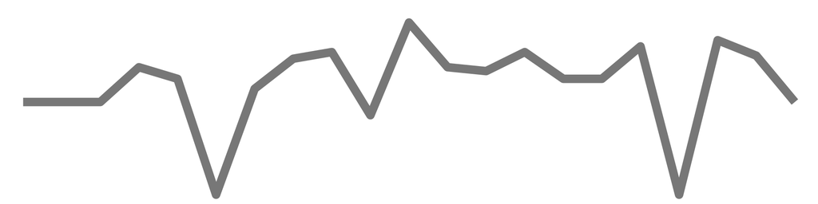

Daniel Baller

11

6

5

14

12

9

8

12

10

8

13

10

10

7

11

11

8

12

3

3

1

0.5

21

0.6740

0.6740

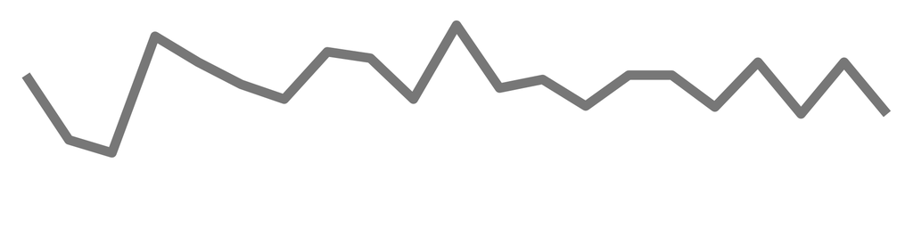

Ira Crofford

9

9

8

10

10

8

9

8

9

9

10

11

13

7

12

11

11

11

5

3

1

0.5

21

0.6740

0.6740

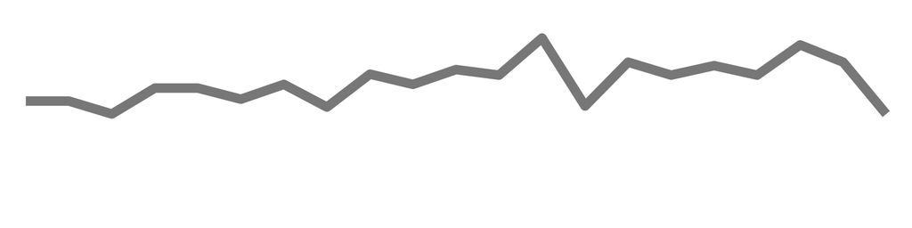

James Jones

11

8

9

11

8

7

NA

10

9

8

11

11

10

7

9

11

11

10

4

3

1

0.5

20

0.6475

0.6167

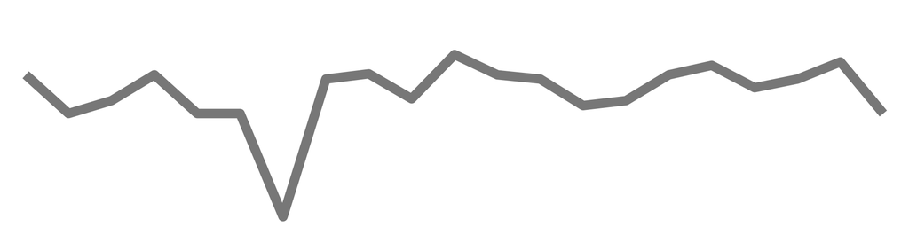

Patrick Mugg

8

8

6

9

8

7

8

11

8

7

9

11

10

8

12

10

NA

11

5

3

1

0.5

20

0.6202

0.5907

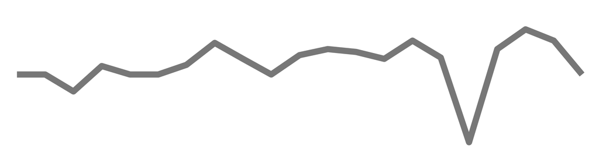

Kevin Cummiskey

7

11

3

7

10

8

9

9

9

7

10

9

10

6

11

8

10

10

3

3

1

0.5

21

0.5897

0.5897

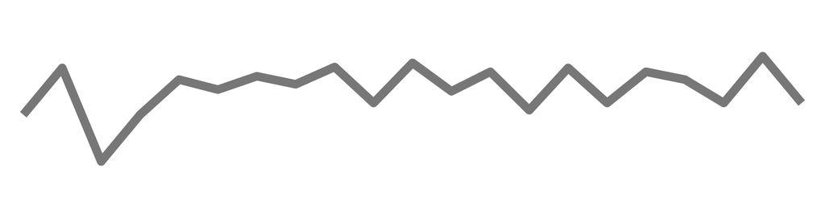

Margaret Wieczorek

10

5

10

5

10

7

10

9

8

4

9

NA

9

8

10

9

9

11

5

2

1

0.5

20

0.5875

0.5595

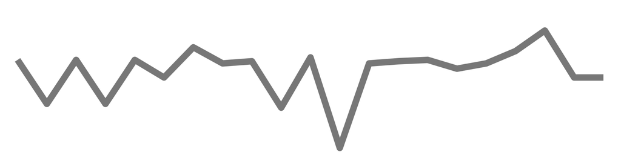

Jonathan Roginski

10

8

8

11

12

7

9

9

9

7

9

10

11

8

11

11

11

8

5

3

0

0.0

21

0.6484

0.6484

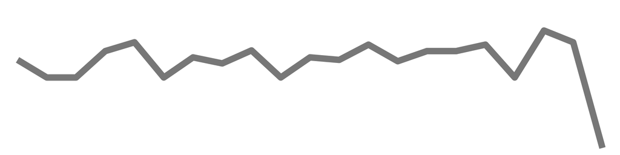

Shane Clark

9

10

9

14

11

7

9

9

9

7

10

10

11

7

NA

9

NA

NA

5

2

NA

0.0

17

0.6549

0.5302

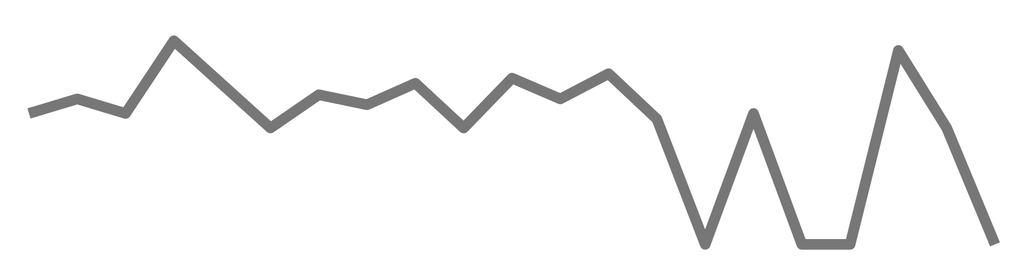

Welvin Lucero

8

NA

NA

NA

8

7

NA

NA

NA

NA

8

NA

9

8

NA

12

11

NA

5

2

NA

0.0

10

0.6190

0.2948

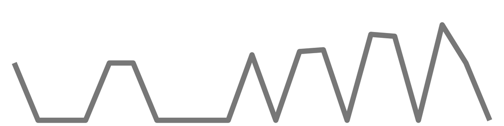

Tina Hartley

9

7

9

8

8

6

12

11

10

6

6

11

9

8

8

9

NA

8

NA

3

NA

0.0

18

0.5920

0.5074

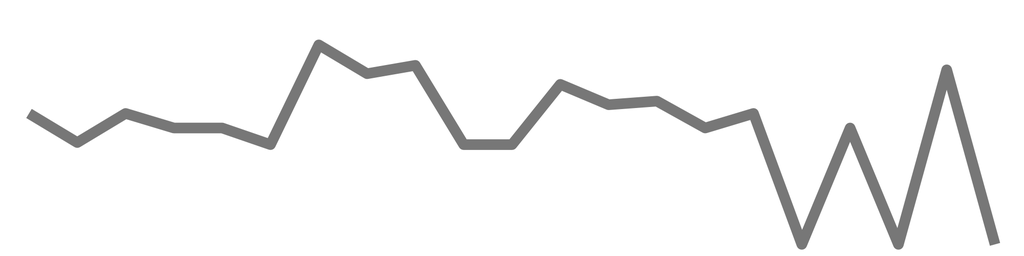

Nicholas Reisweber

6

9

NA

8

NA

NA

NA

NA

NA

NA

NA

NA

NA

NA

NA

NA

NA

NA

NA

NA

NA

0.0

3

0.5111

0.0730

[figure not shown]

James Sherrell

10

7

8

8

8

6

5

7

6

5

9

NA

5

6

7

NA

NA

NA

2

NA

NA

0.0

15

0.4853

0.3466

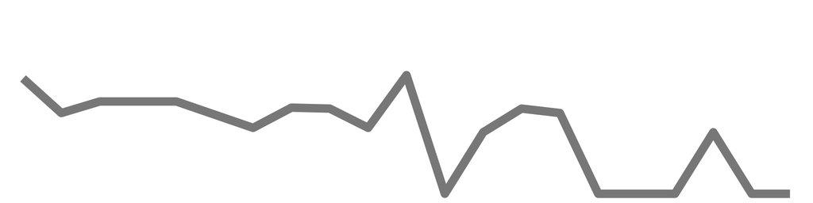

### Individual Plots

[interactive chart not shown]

# Data

|  | Week | Name | Game 1 | Game 2 | Game 3 | Game 4 | Game 5 | Game 6 | Game 7 | Game 8 | Game 9 | Game 10 | Game 11 | Game 12 | Game 13 | Game 14 | Game 15 | Game 16 | Game 1 | Game 3 | Game 4 | Game 5 | Game 6 | Game 7 | Game 8 | Game 9 | Game 10 | Game 11 | Game 12 | … |
| --- | --- | --- | --- | --- | --- | --- | --- | --- | --- | --- | --- | --- | --- | --- | --- | --- | --- | --- | --- | --- | --- | --- | --- | --- | --- | --- | --- | --- | --- | --- |
| 1 | 1 | Margaret Wieczorek | Buffalo Bills | Baltimore Ravens | Cleveland Browns | Houston Texans | Jacksonville Jaguars | New England Patriots | New Orleans Saints | Philadelphia Eagles | Cincinnati Bengals | Chicago Bears | Minnesota Vikings | Kansas City Chiefs | Las Vegas Raiders | Tennessee Titans | Tampa Bay Buccaneers | Seattle Seahawks |  |  |  |  |  |  |  |  |  |  |  | … |
| 2 | 1 | Josephine Cammack | Buffalo Bills | Baltimore Ravens | Carolina Panthers | Indianapolis Colts | Jacksonville Jaguars | New England Patriots | New Orleans Saints | Philadelphia Eagles | Pittsburgh Steelers | Chicago Bears | Minnesota Vikings | Kansas City Chiefs | Las Vegas Raiders | New York Giants | Dallas Cowboys | Seattle Seahawks |  |  |  |  |  |  |  |  |  |  |  | … |
| 3 | 1 | Kevin Cummiskey | Los Angeles Rams | Baltimore Ravens | Carolina Panthers | Houston Texans | Jacksonville Jaguars | New England Patriots | New Orleans Saints | Philadelphia Eagles | Pittsburgh Steelers | San Francisco 49ers | Green Bay Packers | Kansas City Chiefs | Los Angeles Chargers | Tennessee Titans | Tampa Bay Buccaneers | Denver Broncos |  |  |  |  |  |  |  |  |  |  |  | … |
| 4 | 1 | Margaret Reynolds | Buffalo Bills | Baltimore Ravens | Carolina Panthers | Houston Texans | Washington Commanders | New England Patriots | New Orleans Saints | Philadelphia Eagles | Pittsburgh Steelers | Chicago Bears | Green Bay Packers | Arizona Cardinals | Las Vegas Raiders | Tennessee Titans | Tampa Bay Buccaneers | Seattle Seahawks |  |  |  |  |  |  |  |  |  |  |  | … |
| 5 | 1 | James Jones | Buffalo Bills | Baltimore Ravens | Carolina Panthers | Indianapolis Colts | Washington Commanders | Miami Dolphins | New Orleans Saints | Philadelphia Eagles | Pittsburgh Steelers | San Francisco 49ers | Minnesota Vikings | Kansas City Chiefs | Los Angeles Chargers | Tennessee Titans | Tampa Bay Buccaneers | Denver Broncos |  |  |  |  |  |  |  |  |  |  |  | … |
| 6 | 1 | Welvin Lucero | Buffalo Bills | Baltimore Ravens | Carolina Panthers | Indianapolis Colts | Jacksonville Jaguars | Miami Dolphins | New Orleans Saints | Philadelphia Eagles | Cincinnati Bengals | San Francisco 49ers | Minnesota Vikings | Kansas City Chiefs | Las Vegas Raiders | Tennessee Titans | Tampa Bay Buccaneers | Denver Broncos |  |  |  |  |  |  |  |  |  |  |  | … |
| 7 | 1 | Gabriel Costa | Los Angeles Rams | New York Jets | Cleveland Browns | Houston Texans | Washington Commanders | Miami Dolphins | Atlanta Falcons | Philadelphia Eagles | Pittsburgh Steelers | Chicago Bears | Green Bay Packers | Kansas City Chiefs | Los Angeles Chargers | New York Giants | Dallas Cowboys | Denver Broncos |  |  |  |  |  |  |  |  |  |  |  | … |
| 8 | 1 | Jonathan Roginski | Buffalo Bills | Baltimore Ravens | Carolina Panthers | Indianapolis Colts | Washington Commanders | Miami Dolphins | Atlanta Falcons | Philadelphia Eagles | Cincinnati Bengals | San Francisco 49ers | Green Bay Packers | Kansas City Chiefs | Los Angeles Chargers | New York Giants | Tampa Bay Buccaneers | Seattle Seahawks |  |  |  |  |  |  |  |  |  |  |  | … |
| 9 | 1 | Patrick Mugg | Buffalo Bills | Baltimore Ravens | Cleveland Browns | Indianapolis Colts | Washington Commanders | New England Patriots | New Orleans Saints | Detroit Lions | Cincinnati Bengals | San Francisco 49ers | Green Bay Packers | Kansas City Chiefs | Los Angeles Chargers | Tennessee Titans | Tampa Bay Buccaneers | Denver Broncos |  |  |  |  |  |  |  |  |  |  |  | … |
| 10 | 1 | Nicholas Reisweber | Los Angeles Rams | Baltimore Ravens | Carolina Panthers | Indianapolis Colts | Washington Commanders | New England Patriots | Atlanta Falcons | Philadelphia Eagles | Cincinnati Bengals | San Francisco 49ers | Green Bay Packers | Kansas City Chiefs | Los Angeles Chargers | Tennessee Titans | Tampa Bay Buccaneers | Denver Broncos |  |  |  |  |  |  |  |  |  |  |  | … |

[output cut: 300 more lines]

````r
---
title: "2022 NFL Moneyline Picks"
output:
  flexdashboard::flex_dashboard:
    theme:
      version: 4
      bootswatch: spacelab
    orientation: rows
    vertical_layout: fill
    social: ["menu"]
    source_code: embed
    navbar:
      - { title: "Created by: Daniel Baller", icon: "fa-github", href: "https://github.com/danielpballer"  }
---


```{r setup, include=FALSE}
#    source_code: embed
library(flexdashboard)
library(tidyverse)
library(data.table)
library(formattable)
library(ggpubr)
library(ggrepel)
library(gt)
library(glue)
library(ggthemes)
library(hrbrthemes)
library(sparkline)
library(plotly)
library(htmlwidgets)
library(mdthemes)
library(ggtext)
library(ggnewscale)
library(DT)
source("./Functions/functions2.R")

thematic::thematic_rmd(font = "auto")

```

```{r Reading in our picks files, include=FALSE}
current_week = 21 #Set what week it is
week_1 = read_csv("./CSV_Data_Files/2022 NFL Week 1.csv")
week_2 = read_csv("./CSV_Data_Files/2022 NFL Week 2.csv")
week_3 = read_csv("./CSV_Data_Files/2022 NFL Week 3.csv")
week_4 = read_csv("./CSV_Data_Files/2022 NFL Week 4.csv")
week_5 = read_csv("./CSV_Data_Files/2022 NFL Week 5.csv")
week_6 = read_csv("./CSV_Data_Files/2022 NFL Week 6.csv")
week_7 = read_csv("./CSV_Data_Files/2022 NFL Week 7.csv")
week_8 = read_csv("./CSV_Data_Files/2022 NFL Week 8.csv")
week_9 = read_csv("./CSV_Data_Files/2022 NFL Week 9.csv")
week_10 = read_csv("./CSV_Data_Files/2022 NFL Week 10.csv")
week_11 = read_csv("./CSV_Data_Files/2022 NFL Week 11.csv")
week_12 = read_csv("./CSV_Data_Files/2022 NFL Week 12.csv")
week_13 = read_csv("./CSV_Data_Files/2022 NFL Week 13.csv")
week_14 = read_csv("./CSV_Data_Files/2022 NFL Week 14.csv")
week_15 = read_csv("./CSV_Data_Files/2022 NFL Week 15.csv")
week_16 = read_csv("./CSV_Data_Files/2022 NFL Week 16.csv")
week_17 = read_csv("./CSV_Data_Files/2022 NFL Week 17.csv")
week_18 = read_csv("./CSV_Data_Files/2022 NFL Week 18.csv")
week_19 = read_csv("./CSV_Data_Files/2022 NFL Wild Card.csv")
week_20 = read_csv("./CSV_Data_Files/2022 NFL Divisional Round.csv")
week_21 = read_csv("./CSV_Data_Files/2022 NFL Conference Round.csv")
# week_22 = read_csv("./CSV_Data_Files/2022 NFL Super Bowl.csv")

#reading in scores
Scores = read_csv(glue::glue("./CSV_Data_Files/NFL_Scores_{current_week}.csv"))

#reading in CBS Prediction Records
cbs = read_csv(glue::glue("./CSV_Data_Files/CBS_Experts_{current_week}.csv")) %>%
  mutate(Percent = round(Percent,4))
cbs_season = read_csv(glue::glue("./CSV_Data_Files/CBS_Experts_Season_{current_week}.csv"))

#reading in ESPN Prediction Records
espn = read_csv(glue::glue("./CSV_Data_Files/ESPN_Experts_{current_week}.csv"))%>%
  mutate(Percent = round(Percent,4))
espn_season = read_csv(glue::glue("./CSV_Data_Files/ESPN_Experts_Season_{current_week}.csv"))%>%
  mutate(Percent = round(Percent,4))

#Odds not working for the 2022 season.  Need to fix scrape code for next year.
#Reading in the moneyline odds for each team and cleaning the team names
# odds_wk1 = read_csv(glue::glue("./CSV_Data_Files/Moneyline_Odds_1.csv"))
# odds_wk2 = read_csv(glue::glue("./CSV_Data_Files/Moneyline_Odds_2.csv"))
# odds_wk3 = read_csv(glue::glue("./CSV_Data_Files/Moneyline_Odds_3.csv"))
# odds_wk4 = read_csv(glue::glue("./CSV_Data_Files/Moneyline_Odds_4.csv"))
# odds_wk5 = read_csv(glue::glue("./CSV_Data_Files/Moneyline_Odds_5.csv"))
# odds_wk6 = read_csv(glue::glue("./CSV_Data_Files/Moneyline_Odds_6.csv"))
# odds_wk7 = read_csv(glue::glue("./CSV_Data_Files/Moneyline_Odds_7.csv"))
# odds_wk8 = read_csv(glue::glue("./CSV_Data_Files/Moneyline_Odds_8.csv"))
# odds_wk9 = read_csv(glue::glue("./CSV_Data_Files/Moneyline_Odds_9.csv"))
# odds_wk10 = read_csv(glue::glue("./CSV_Data_Files/Moneyline_Odds_10.csv"))
# odds_wk11 = read_csv(glue::glue("./CSV_Data_Files/Moneyline_Odds_11.csv"))
# odds_wk12 = read_csv(glue::glue("./CSV_Data_Files/Moneyline_Odds_12.csv"))
# odds_wk13 = read_csv(glue::glue("./CSV_Data_Files/Moneyline_Odds_13.csv"))
# odds_wk14 = read_csv(glue::glue("./CSV_Data_Files/Moneyline_Odds_14.csv"))
# odds_wk15 = read_csv(glue::glue("./CSV_Data_Files/Moneyline_Odds_15.csv"))
# odds_wk16 = read_csv(glue::glue("./CSV_Data_Files/Moneyline_Odds_16.csv"))
# odds_wk17 = read_csv(glue::glue("./CSV_Data_Files/Moneyline_Odds_17.csv"))
# odds_wk18 = read_csv(glue::glue("./CSV_Data_Files/Moneyline_Odds_18.csv"))
# odds_wk19 = read_csv(glue::glue("./CSV_Data_Files/Moneyline_Odds_19.csv"))
# odds_wk20 = read_csv(glue::glue("./CSV_Data_Files/Moneyline_Odds_20.csv"))
# odds_wk21 = read_csv(glue::glue("./CSV_Data_Files/Moneyline_Odds_21.csv"))
# odds_wk22 = read_csv(glue::glue("./CSV_Data_Files/Moneyline_Odds_22.csv"))

####################UPDATE THESE###############################
inst.picks = list(week_1, week_2, week_3, week_4, week_5, week_6, week_7, week_8, week_9, week_10, week_11,
                  week_12, week_13, week_14, week_15, week_16, week_17, week_18, week_19,
                  week_20, week_21) #add in the additional weeks
# odds = rbind(odds_wk1, odds_wk2, odds_wk3, odds_wk4, odds_wk5, odds_wk6, odds_wk7, odds_wk8,
#              odds_wk9, odds_wk10, odds_wk11, odds_wk12) #add in the additional weeks
####################END OF UPDATE##############################

weeks = as.list(seq(1:current_week)) #creating a list of each week number
```

```{r read in scores clean data, include=FALSE}
#Cleaning Odds Data
# cl_odds = odds_cleaning(odds)

#Cleaning scores data
Scores = cleaning2(Scores)

#creating a list of winners for each week
winners = map(weeks, weekly_winners)

#creating a vector of this weeks winners
this_week = pull(winners[[length(winners)]])

#Getting the number of games for each week
weekly_number_of_games = map_dbl(weeks, week_number_games)
```

```{r Group Predictions, include=FALSE}
#Creating the list of everyones predictions each week.
games = map(inst.picks, games_fn)

#Creating the prediction table.
pred_table = map(games, pred_table_fn)

#Adding who won to the predictions
with_winners = map2(pred_table, winners, adding_winners)
````

````r
#Creating results for each week.
results = map2(with_winners,weekly_number_of_games, results_fn)
```


```{r Displaying Group Results, echo=FALSE}
#Displaying the group results

inst_group_table = results[[length(results)]] %>% gt() %>%
  cols_align(
    align = "center") %>%
   tab_header(
    title = md("This Week's Predictions"),
    subtitle = md(glue("Week {length(results)}"))
    ) %>%
   tab_style(
    style = cell_text(color = "red", weight = "bold"),
    locations = cells_body(
      columns = c(Correct),
      rows = Correct =="No"
    )) %>%
   tab_style(
    style = cell_text(color = "green", weight = "bold"),
    locations = cells_body(
      columns = c(Correct),
      rows = Correct =="Yes"
    )) %>%
  tab_options(
    data_row.padding = px(3),
    container.height = "100%"
   )
```

```{r Weekly and season Group Results, include=FALSE}
# Printing the weekly and season win percentage

#how many games correct, incorrect, and not picked each week
weekly_group_correct = map(results, weekly_group_correct_fn)

#how many games were picked each week
weekly_games_picked = map2(weekly_group_correct, weekly_number_of_games, weekly_games_picked_fn)

#Calculating the number of correct picks for each week
weekly_group_correct_picks = map(weekly_group_correct, weekly_group_correct_picks_fn)

#Calculating weekly win percentage
weekly_win_percentage = map2(weekly_group_correct_picks, weekly_games_picked, weekly_win_percentage_fn)

#Calculating season win percentage
season_win_percentage = round(sum(unlist(weekly_group_correct_picks))/sum(unlist(weekly_games_picked)),4)

#Calculating number of games picked this season
season_games = sum(unlist(weekly_games_picked))

#calculating season wins
season_wins = sum(unlist(weekly_group_correct_picks))

#calculating the number of people who picked this week
Total = dim(inst.picks[[length(weeks)]])[1]
```

```{r plotting group results, include=FALSE}
#Previous Weeks
group_season_for_plotting = unlist(weekly_win_percentage) %>% as.data.frame() %>%
  rename(`Win Percentage` = ".") %>%
  add_column(Week = unlist(weeks))
```

```{r Plotting the group results, echo=FALSE}
inst_group_season_plot = group_season_for_plotting %>%
ggplot(aes(x = as.factor(Week), y = `Win Percentage`))+
  geom_point()+
  geom_path(aes(x = Week))+
  ylim(c(0, 1)) +
  xlab("NFL Week") +
  ylab("Correct Percentage")+
  ggtitle("Weekly Group Correct Percentage")+
  theme_classic()+
  theme(plot.title = element_text(hjust = 0.5, size = 18))
```

```{r instructor beating cbs week, include=FALSE}
#Creating a list of correct percentages for each week.
cbs_weekly_percent = map(weeks, cbs_percent)

#Creating a list of how many cbs experts we beat each week.
cbs_experts_beat = map2(cbs_weekly_percent, weekly_win_percentage, experts_beat)

#Creating a list of how many cbs experts picked each week.
cbs_experts_total = map(cbs_weekly_percent, experts_tot)
```

```{r instructor beating cbs season, include=FALSE}
#Creating a list of correct percentages for each week.
cbs_season_percent = map(weeks, cbs_season_percent)

#Creating a list of how many cbs experts we beat each week.
cbs_experts_beat_season = map2(cbs_season_percent, season_win_percentage, experts_beat)

#Creating a list of how many cbs experts picked each week.
cbs_experts_season_total = map(cbs_season_percent, experts_tot)
```

```{r instructor beating ESPN week, include=FALSE}
#Creating a list of correct percentages for each week.
espn_weekly_percent = map(weeks, espn_percent)

#Creating a list of how many cbs experts we beat each week.
espn_experts_beat = map2(espn_weekly_percent, weekly_win_percentage, experts_beat)

#Creating a list of how many cbs experts picked each week.
espn_experts_total = map(espn_weekly_percent, experts_tot)
```

```{r instructor beating ESPN season, include=FALSE}
#Creating a list of correct percentages for each week.
espn_season_percent = map(weeks, espn_season_percent)

#Creating a list of how many cbs experts we beat each week.
espn_experts_beat_season = map2(espn_season_percent, season_win_percentage, experts_beat)

#Creating a list of how many cbs experts picked each week.
espn_experts_season_total = map(espn_season_percent, experts_tot)
```

```{r individual results, include=FALSE}
#Creating a list of individual results for each week.
weekly_indiv = pmap(list(inst.picks, winners, weeks), indiv_weekly_pred)

#Combining each week into one dataframe and calculating percentage Correct for this week.
full_season = weekly_indiv %>% reduce(full_join, by = "Name") %>%
  mutate(Percent = round(pull(.[,ncol(.)]/weekly_number_of_games[[length(weekly_number_of_games)]]),4))

#Creating a dataframe with only the weekly picks
a = full_season %>% select(starts_with("Week"))

#Creating a vector of how many weeks each person picked over the season
tot_week = NULL
help = NULL
for (i in 1:dim(a)[1]){
  for(j in 1:length(a)){
    help[j] = ifelse(is.na(a[i,j])==T,0,1)
    tot_week[i] = sum(help)
  }
}

#Creating a vector of how many games each person picked over the season
tot_picks= NULL
help = NULL
for (i in 1:dim(a)[1]){
  for(j in 1:length(a)){
    help[j] = unlist(weekly_games_picked)[j]*ifelse(is.na(a[i,j])==T,0,1)
    tot_picks[i] = sum(help)
  }
}

#Creatign a vector of how many games each person picked correct over the season
tot_correct = NULL
help = NULL
for (i in 1:dim(a)[1]){
  tot_correct[i] = sum(a[i,], na.rm = T)
}

#adding how many weeks each person picked, season correct percentage, and adjusted season percentag to the data frame and sorting the data
indiv_disp = full_season %>% add_column(`Weeks Picked` = tot_week) %>%
  add_column(tot_correct)%>%
  add_column(tot_picks)%>%
  mutate(`Season Percent` = round(tot_correct/tot_picks,4))%>%
  mutate(`Adj Season Percent` = round(`Season Percent`*(tot_week/length(a)),4)) %>%
  select(-tot_correct, -tot_picks) %>%
  arrange(desc(Percent), desc(`Season Percent`)) %>%
  mutate(Percent = ifelse(is.na(Percent)==T, 0, Percent))
```

```{r individual percentages, include=FALSE}
#Calculating individual percentages for each week.
weekly_indiv_percent = map2(weekly_indiv, as.list(weekly_number_of_games), indiv_percent) %>% reduce(full_join, by = "Name")
````

````r
weekly_indiv_percent_plot = weekly_indiv_percent %>%
  pivot_longer(cols = starts_with("Week"), names_to = "Week", values_to = "Percent")%>%
  mutate(Percent = ifelse(is.na(Percent)==T, 0, Percent)) %>%
  mutate(Week = as.factor(Week))

levels = NULL
for(i in 1:length(weeks)){
  levels[i] = glue("Week {i}")
}

weekly_indiv_percent_plot = weekly_indiv_percent_plot %>%
  mutate(Week = factor(Week, levels))
```

```{r sparklines, include=FALSE}
#adding sparklines
plot_group = function(name, df){
  plot_object =
    ggplot(data = df,
           aes(x = as.factor(Week), y=Percent, group = 1))+
    geom_path(size = 7)+
    scale_y_continuous(limits = c(0,1))+
    theme_void()+
    theme(legend.position = "none")
  return(plot_object)
}

sparklines =
  weekly_indiv_percent_plot %>%
  group_by(Name) %>%
  nest() %>%
  mutate(plot = map2(Name, data, plot_group)) %>%
  select(-data)

indiv_disp_2 = indiv_disp %>%
  inner_join(sparklines, by = "Name") %>%
  mutate(`Season Trend` = NA)
```

```{r Printing Individual Table2, echo=FALSE}
# Printing the individual Table
indiv_table = indiv_disp_2 %>% gt() %>%
  cols_align(
    align = "center") %>%
   tab_header(
    title = md("Individual Results"),
    subtitle = md(glue("Week {length(weeks)}"))
    ) %>%
   tab_style(
    style = cell_text(color = "red", weight = "bold"),
    locations = cells_body(
      columns = c(Percent),
      rows = Percent<.5
    )) %>%
   tab_style(
    style = cell_text(color = "green", weight = "bold"),
    locations = cells_body(
      columns = c(Percent),
      rows = Percent>.5
    )) %>%
     tab_style(
    style = cell_text(color = "red", weight = "bold"),
    locations = cells_body(
      columns = c(`Season Percent`),
      rows = `Season Percent`<.5
    )) %>%
   tab_style(
    style = cell_text(color = "green", weight = "bold"),
    locations = cells_body(
      columns = c(`Season Percent`),
      rows = `Season Percent`>.5
    ))%>%
     tab_style(
    style = cell_text(color = "red", weight = "bold"),
    locations = cells_body(
      columns = c(`Adj Season Percent`),
      rows = `Adj Season Percent`<.5
    )) %>%
   tab_style(
    style = cell_text(color = "green", weight = "bold"),
    locations = cells_body(
      columns = c(`Adj Season Percent`),
      rows = `Adj Season Percent`>.5
    )) %>%
  tab_options(
    container.width = pct(100),
    data_row.padding = px(1),
    container.height = "100%"
   ) %>%
    tab_spanner(
    label = "Weekly # Correct",
    columns = starts_with(c("Week "))
  ) %>%
  text_transform(
    locations = cells_body(c(`Season Trend`)),
    fn = function(x){
      map(indiv_disp_2$plot, ggplot_image, height = px(30), aspect_ratio = 4)
                 }) %>%
  cols_hide(c(plot))

indiv_winners = indiv_disp_2 %>% filter(Percent == max(Percent)) %>% select(Name) %>% pull() %>% paste(collapse = ", ")
indiv_season = indiv_disp_2 %>% filter(`Season Percent` == max(`Season Percent`)) %>% select(Name) %>% pull() %>% paste(collapse = ", ")
indiv_season_adj = indiv_disp_2 %>% filter(`Adj Season Percent` == max(`Adj Season Percent`)) %>% select(Name) %>% pull()%>% paste(collapse = ", ")
```

```{r instructor formattable, echo=FALSE}
improvement_formatter <-
  formatter("span",
            style = x ~ formattable::style(
              font.weight = "bold",
              color = ifelse(x > .5, "green", ifelse(x < .5, "red", "black"))),
             x ~ icontext(ifelse(x == max(x), "star", ""), x))

indiv_disp_3 = indiv_disp_2 %>% select(-plot)
indiv_disp_3$`Season Trend` = apply(indiv_disp_3[,2:(1+length(weeks))], 1, FUN = function(x) as.character(htmltools::as.tags(sparkline(as.numeric(x), type = "line", chartRangeMin = 0, chartRangeMax = 1, fillColor = "white"))))

indiv_table_2 = as.htmlwidget(formattable(indiv_disp_3,
                                align = c("l", rep("c", NROW(indiv_disp_3)-1)),
              list(`Season Percent` = color_bar("#FA614B"),
              `Season Percent`= improvement_formatter,
              `Adj Season Percent`= improvement_formatter)))

indiv_table_2$dependencies = c(indiv_table_2$dependencies, htmlwidgets:::widget_dependencies("sparkline", "sparkline"))
```

```{r Plotting individual results over the season2, echo=FALSE, out.width = "100%"}
#Creating the individual plot.
inst_indiv_plots = weekly_indiv_percent_plot %>%
  ggplot(aes(x = factor(Week), y = Percent, color = Name))+
  geom_point()+
  geom_path(aes(x = as.factor(Week), y = Percent, color = Name,
                group = Name))+
  ylim(c(0, 1)) +
  labs(x = "NFL Week",
       y = "Correct Percentage",
       title = "Weekly Individual Correct Percentage")+
  facet_wrap(~Name)+
  theme_classic()+
  theme(legend.position = "none",
        plot.title = element_text(hjust = 0.5, size = 18),
        axis.text.x=element_text(angle =45, vjust = 1, hjust = 1))
```

<!--
```{r Plotting individual results over the season, include=FALSE, out.width="100%"}
#Creating the individual plot.
indiv_plot_comb = weekly_indiv_percent %>%
  pivot_longer(cols = starts_with("Week"), names_to = "Week", values_to = "Percent") %>%
  mutate(Percent = ifelse(is.na(Percent)==T, 0, Percent)) %>%
  #group_by(Name) %>%
  ggplot(aes(x = as.factor(Week), y = Percent, color = Name))+
  geom_point()+
  geom_line(aes(x = as.factor(Week), y = Percent, color = Name,
                group = Name))+
  ylim(c(0, 1)) +
  labs(x = "NFL Week",
       y = "Correct Percentage",
       title = "Weekly Individual Correct Percentage")+
  theme_classic()+
  theme(#legend.position = "none",
        plot.title = element_text(hjust = 0.5, size = 18))
```
-->


```{r data for data page}
inst.data = map2(inst.picks, weeks, disp_data) %>% bind_rows()
```


```{r fivethirtyeight}
inst_538 = map(results, five38) %>% unlist() %>% sum()
```

```{r pregame, eval=FALSE, include=FALSE}
#Predictions for the week

#Creating the list of group predictions each week.
games = map(inst.picks, games_fn)

#Creating the prediction table.
pred_table = map(games, pred_table_fn)
````

````r
#Printing table of instructor predictions
pred_table[[length(pred_table)]] %>% mutate(Game = row_number()) %>%
  rename(`Votes For` = votes_for, `Votes Against` = votes_against) %>%
  gt() %>%
  cols_align(
    align = "center") %>%
   tab_header(
    title = md("This Week's Predictions"),
    subtitle = md(glue("Week {length(weeks)}"))
    ) %>%
   tab_options(
    data_row.padding = px(3)
   )
```

Group Predictions
==========================================================================

Sidebar {.sidebar}
-------------------------------------
#### CBS Sports

<font size="4">

This week we beat or tied `r cbs_experts_beat[[length(weeks)]]` of `r cbs_experts_total[[length(weeks)]]` CBS Sports' Experts.

For the season we are currently beating or tied with `r cbs_experts_beat_season[[length(weeks)]]` of `r cbs_experts_season_total[[length(weeks)]]` CBS Sports' Experts.

 </font>


#### ESPN

<font size="4">

We also beat or tied `r espn_experts_beat[[length(weeks)]]` of `r espn_experts_total[[length(weeks)]]` ESPN Experts.

For the season we are currently beating or tied with `r espn_experts_beat_season[[length(weeks)]]` of `r espn_experts_season_total[[length(weeks)]]` ESPN Experts.

</font>

Row
--------------------------------------

### Win percentage for the week

```{r}
inst_rate <- weekly_win_percentage[[length(weekly_win_percentage)]]*100
gauge(inst_rate, min = 0, max = 100, symbol = '%', gaugeSectors(
  success = c(55, 100), warning = c(40, 54), danger = c(0, 39)
))
```

### Season Win Percentage

```{r}
inst_season <- season_win_percentage*100
gauge(inst_season, min = 0, max = 100, symbol = '%', gaugeSectors(
  success = c(55, 100), warning = c(40, 54), danger = c(0, 39)
))
```

### Games Correct
```{r}
valueBox(value = season_wins,icon = "fa-trophy",caption = "Correct Games this Season")
```

### Games Picked
```{r}
valueBox(value = season_games,icon = "fa-clipboard-list",caption = "Games Picked this Season")
```

### Number of predictions
```{r}
valueBox(value = Total,icon = "fa-users",caption = "Predictions this week")
```

Row
--------------------------------------

###

```{r}
inst_group_table
```

###

```{r}
ggplotly(inst_group_season_plot) %>%
  layout(title = list(y = .93, xref = "plot"),
         margin = list(t = 40))
```

Individual Predictions
==========================================================================


Sidebar {.sidebar}
-------------------------------------

#### Best Picks of the Week.

<font size="4">

 `r indiv_winners`

 </font>

#### Best Season Correct Percentage
<font size="4">

`r indiv_season`

 </font>

#### Best Adjusted Season Correct Percentage
<font size="4">

`r indiv_season_adj`

 * Adjusted season percentage accounts for the number of weeks picked.

 </font>

row {.tabset}
--------------------------------------

### Individual Table
```{r}
indiv_table
```

<!--
### Individual Table2

```{r, out.height="100%"}
indiv_table_2
```
-->
### Individual Plots
```{r, out.width="100%"}
ggplotly(inst_indiv_plots)
```


Data
==========================================================================

```{r}
datatable(
  inst.data, extensions = 'Buttons', options = list(
    dom = 'Blfrtip',
    buttons = c('copy', 'csv', 'excel', 'pdf', 'print'),
    lengthMenue = list( c(10, 25, 50, 100, -1), c(10, 25, 50, 100, "All") )
  )
)
```
````